# Zusammenhang zwischen den Wortfolgen und den Wortstellungen in Nominalphrasen von Sprachen der Welt

Huan Wei, Master LinKoKo, Mart.-Nr. 2471884

2018-03-07

# 1. Einleitung

Sprache der Welt & Sprachtypologie

Idee fürs Umfrage etc.

# 2. Eigene Untersuchung

Um den Zusammenhang zwischen der Wortfolge im Satz und Nominalphrase in der Sprache herauszufinden, wurde einen Fragebogen mit 10-deutschen Sätzen an Informanten mit verschiedene Muttersprachen gegeben. Von Januar bis Ende Februar 2018 habe ich insgesamt 26 Fragebogen von Informanten zurückbekommen.

## 2.1 Überlegungen zur Wahl der Informanten und Sprachen

Die Überlegungen zur Wahl der Personen war es, dass wir nur die Muttersprachler suchen. Denn die L2-Leaner sind meistens unsicher für die Übersetzung und brauchen Lehrbücher oder Wörterbuch, um den Übersetzungsbögen ins anderen Sprachen zu übersetzen.

Die erhobenen Sprachen sind gut auf den Sprachfamilien geteilt. Es gibt nicht nur Indoeuropäische Sprachen wie Deutsch, Englisch, Niederländisch, Französisch, Spanisch, Italienisch, Griechisch, Portugiesisch, Polnisch, Russisch, Ukrainisch, Rumänisch, Hindi, Kroatisch und Persisch, sondern auch die isolierten Sprachen wie Koreanisch, Japanisch und Chinesisch. Außerdem sind die Altaische Sprachen wie Türkisch, Afroasiatische Sprachen wie Tigrinja und Berber, Sinotibetische Sprachen wie Kantonesisch, Austroasiatische Sprache wie Vietnamesisch, Austronesisch wie Indonesisch und Südkaukasische Sprachen wie Georgisch. (vgl. Wals.info)

Im Folgenden werden die Daten von den erhobenen Sprachen in “R” eingelesen und schließlich wird eine Karte für eine Übersicht der erhobenen Sprachen mit diesen Daten dargestellt.

```r
Karte <- read.csv ("//Users/verawei/Desktop/HA Sprachtypologie/sources/Karte.csv"
                    , header = TRUE
                   , sep = ";")
```

```r
summary(Karte)
```

```
##         Sprache                 Land       Latitude       Longitude
##  Armenisch  : 1   China           : 2   Min.   : 0.00   Min.   :-99.38
##  Berber     : 1   Iran            : 2   1st Qu.:32.17   1st Qu.: 10.50
##  Chinesisch : 1   Deutschland     : 1   Median :39.00   Median : 34.00
##  Deutsch    : 1   England         : 1   Mean   :36.66   Mean   : 41.68
##  Englisch   : 1   Ethiopia Eritrea: 1   3rd Qu.:47.50   3rd Qu.: 71.25
##  Französisch: 1   Frankreich      : 1   Max.   :56.00   Max.   :140.00
##  (Other)    :20   (Other)         :18
```

Im Bild 1 werden alle erhobenen Sprachen nach ihrer Räumlichkeit auf der Weltkarte dargestellt. Mit diesem Bild sieht man, dass die erhobene Sprachen gut auf der ganzen Welt geteilt sind. Die meisten Sprachen sind von Europa, aber asiatische und afrikanische Sprachen sind auch dabei.

#### Bild 1: Übersicht der erhobenen Sprachen

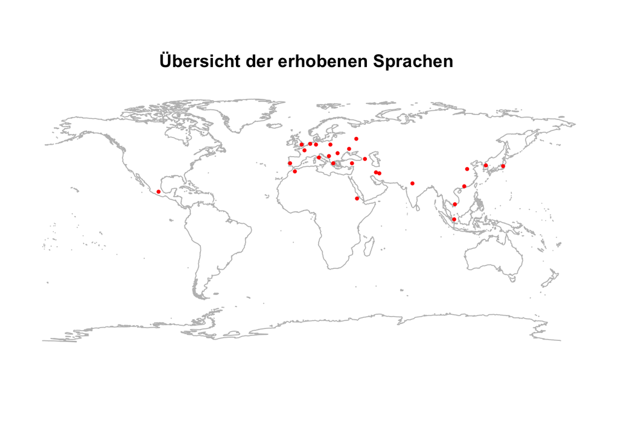

```r
library(maps)
map("world", interior=FALSE, col="grey", resolution=0)

points(Karte$Longitude, Karte$Latitude
       , col = "red"
       , cex =.7
       , pch = 20)

title (main = "Übersicht der erhobenen Sprachen ")
```

```r
Umfrage <- read.csv ("//Users/verawei/Desktop/HA Sprachtypologie/sources/Umfrage.csv"
                    , header = TRUE
                    , sep = ";")
```

```r
summary(Umfrage)
```

```
##         Sprache                 Land        Gattung              Familie
##  Armenisch  : 1   China           : 2   Romance : 5   1 Indo-European:16
##  Berber     : 1   Iran            : 2   Slavic  : 4   3 Afro-Asiatic : 2
##  Chinesisch : 1   Deutschland     : 1   Germanic: 3   10 Kartvelian  : 1
##  Deutsch    : 1   England         : 1   Armenian: 1   2 Altaic       : 1
##  Englisch   : 1   Ethiopia Eritrea: 1   Berber  : 1   4 Chinesisch   : 1
##  Französisch: 1   Frankreich      : 1   Chinese : 1   5 Sino-Tibetan : 1
##  (Other)    :20   (Other)         :18   (Other) :11   (Other)        : 4
##     Latitude       Longitude      Wortfolge              Adjektiv.Nomen
##  Min.   : 0.00   Min.   :-99.38   1 SVO:20   1 1 Adj+N          : 1
##  1st Qu.:32.17   1st Qu.: 10.50   2 SOV: 6   1 Adj+N            :16
##  Median :39.00   Median : 34.00              2 N+Adj            : 7
##  Mean   :36.66   Mean   : 41.68              3 No dominant order: 2
##  3rd Qu.:47.50   3rd Qu.: 71.25
##  Max.   :56.00   Max.   :140.00
##
##  Musik.Mozart Artikel.Nomen Farbe.Nomen Numeral.Nomen  Artikel.Farbe
##  1 MuMo:15    1 DET+N:23    1 Fa+N:18   1 Num+N:26    1 DET+Fa:18
##  2 MoMu: 9    2 N+DET: 2    2 N+Fa: 8                 2 Fa+DET: 1
##  NA's  : 2    NA's   : 1                              NA's    : 7
##
##
##
##
##   Artikel.Numeral  Artikel.Adjektiv  Farbe.Adjektiv
##  1 DET+Num:21     1 DET+Adj:22      1 Adj+Fa:20
##  2 Num+DET: 4     2 Adj+DET: 2      2 Fa+Adj: 6
##  NA's     : 1     NA's     : 2
##
##
##
##
##  Adjektiv.Adjektiv.Umfang
##  1 Adj+Adj-U:16
##  2 Adj-U+Adj: 8
##  NA's       : 2
##
##
##
##
```

In Folgenden Bild 2 werden diese erhobenen Sprachen nach der Sprachfamilie dargestellt. Mit dieser Darstellung kann man einen besseren Überblick über die zusammengehörige Sprachfamilie. Die erhobenen Sprachen sind gut auf den Sprachfamilien geteilt. Es gibt 16 Indoeuropäische Sprachen und zwei Afroasiatische Sprachen. Außerdem sind die Sprachfamilie Südkaukasische Sprachen, Altaische Sprachen, Austroasiatische Sprachen, Austronesische Sprache, Sinotibetische Sprachen, Chinesisch, Japanisch und Koreanisch auch dabei. Darüber hinaus kann man sagen, dass die erhobenen 26 Sprachen sehr vielfältig sind.

#### Bild 2: Übersicht der erhobenen Sprachen nach der Sprachfamilie

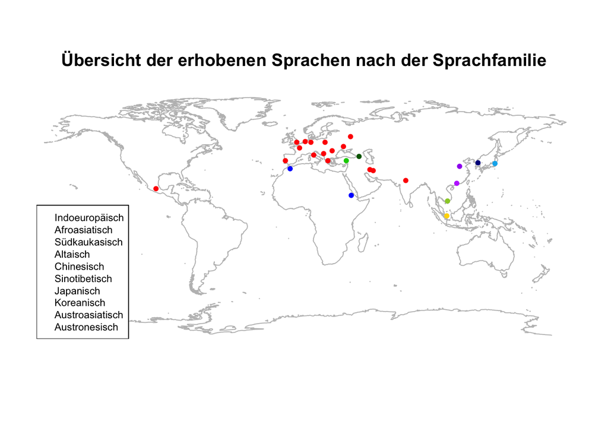

```r
maps::map("world"
          ,interior = FALSE
          , col = "grey"
          , resolution = 0)

cols <- c("red", "darkgreen", "green3", "blue","purple","darkorchid1", "deepskyblue2", "darkblue", "yellowgreen", "gold")
mycols <- cols[Umfrage$Familie]

mysymbols <- c(20, 20, 20, 20, 20, 20, 20, 20, 20, 20)
Sprachefamilie <- mysymbols[Umfrage$Familie]

myname <- c("Indoeuropäisch", "Afroasiatisch", "Südkaukasisch", "Altaisch", "Chinesisch", "Sinotibetisch", "Japanisch", "Koreanisch", "Austroasiatisch", "Austronesisch")

points(Umfrage$Longitude, Umfrage$Latitude
       , pch = Sprachefamilie
       , col = mycols)

title(main = "Übersicht der erhobenen Sprachen nach der Sprachfamilie")

legend ("bottomleft"
        , legend = myname
     #   , pch = Sprachfamilie
        , col = cols
        , cex = 0.7
        , pt.cex = 1.5)
```

Die Auswahl von Farben in der Karte sind schwierig. Eine Seite sollten die näh zusammengehörige Sprachfamilie eine ähnliche Farbe bekommen, andere Seite sollten die Ortspunkte von Sprachen gut auffällig sind.

## 2.2 Übersetzungssätzen

Dieser Übersetzungsbogen wurde von mir und zwei weiteren Studentinnen zusammengestellt. Mit diesem Übersetzungsbogen möchten wir herausfinden, wie bestimmte Sätze in verschiedene Sprachen aufgebaut sind, wie Superlativ und Modalpartikeln. Ich interessiere mich sehr über den Zusammenhang zwischen den Wortfolgen und den Wortstellungen in Nominalphrasen von Sprachen der Welt.

Daher enthält der Übersetzungsbogen folgende Zehn Sätze: 1. Ich koche Suppe. 2. Der Bäcker backt ja das Brot am schnellsten. 3. Die Schüler hören am liebsten Musik von Mozart. 4. Die Touristen sehen diese fünf großen Häuser. 5. Die Kinder werfen doch einen schönen großen roten Ball. 6. Was machst du denn? 7. Du hast eben nicht genug gelernt! 8. Tim wirft den Ball am weitesten. 9. Kleine Hunde bellen aber am lautesten. 10. Das feuchte Holz verbrennt am schlechtesten.

Für mein Analysieren sind nur folgende Satzteilen relevant: - 1. Ich koche Suppe. [Subjekt + Verb + Objekt] - 3. Musik von Mozart [ Nomen + Nomen] - 4. diese fünf großen Häuser [DET + Num + Adj-Umfang + N] - 5. einen schönen großen roten Ball [ ART + Adj + Adj-Umfang + Farbe + N] - 9. kleine Hunde [Adj + N] - 10. das feuchte Holz [DET + Adj + N]

Mit Satz 1 möchte ich die Wortfolgen im Satz von der Sprache festzustellen. Leider gibt es viele Sprachen, wenn der Subjekt im Satz “ich” ist, fällt den Subjekt weg und wird mit der Endung von Verb markiert. Daher habe ich die Wortfolgen von der Sprache immer auf alle gefragte zehn Sätzen berücksichtigt. “Musik von Mozart” sind zwei Nomen, daher analysiere ich nur die Rheinfolge von “Musik” und “Mozart”.

## 2.3 Methode und Ablauf

Die meisten Informanten sind meine Arbeitskollegen, Freunden oder Kommilitonen. Durch persönliche Gespräche, E-Mails und Nachtrichten von Facebook habe ich sie als Informanten gewinnen. Die Übersetzungsbogen sind entweder in ausgedrückten Papierformen an Informanten persönlich gegeben, oder als Word- oder PDF-Datei an Informanten per E-Mail erreichtet.

# 3. Ergebnisse der Umfrage

## 3.1 Einlesen der gesamten Ergebnisse der Umfrage

```r
Umfragesdaten <- read.csv("../sources/Daten_Umfrage.csv"
                          , header = TRUE
                          , sep = ";"
                          , quote = ""
                          )
```

```r
summary(Umfragesdaten)
```

```
##         Sprache                 Land       Latitude       Longitude
##  Armenisch  : 1   China           : 2   Min.   : 0.00   Min.   :-99.38
##  Berber     : 1   Iran            : 2   1st Qu.:32.17   1st Qu.: 10.50
##  Chinesisch : 1   Deutschland     : 1   Median :39.00   Median : 34.00
##  Deutsch    : 1   England         : 1   Mean   :36.66   Mean   : 41.68
##  Englisch   : 1   Ethiopia Eritrea: 1   3rd Qu.:47.50   3rd Qu.: 71.25
##  Französisch: 1   Frankreich      : 1   Max.   :56.00   Max.   :140.00
##  (Other)    :20   (Other)         :18
##  Wortfolge Adjektiv.Nomen Musik.Mozart Artikel.Nomen Farbe.Nomen
##  SOV: 6    Adj+N :17      MoMu: 9      DET+N:23      Fa+N:18
##  SVO:20    Beides: 2      MuMo:15      N+DET: 2      N+Fa: 8
##            N+Adj : 7      NA's: 2      NA's : 1
##
##
##
##
##  Numeral.Nomen Artikel.Farbe Artikel.Numeral Artikel.Adjektiv
##  Num+N:26      DET+Fa:18     DET+Num:21      Adj+DET: 2
##                Fa+DET: 1     Num+DET: 4      DET+Adj:22
##                NA's  : 7     NA's   : 1      NA's   : 2
##
##
##
##
##  Farbe.Adjektiv Adjektiv.Adjektiv.Umfang
##  Adj+Fa:20      Adj-U+Adj: 8
##  Fa+Adj: 6      Adj+Adj-U:16
##                 NA's     : 2
##
##
##
##
```

## 3.2 Die Wortfolge von Subjekt, Objekt und Verb der erhobenen Sprachen

#### Bild 3: Die Wortfolge von Subjekt, Objekt und Verb der erhobenen Sprachen

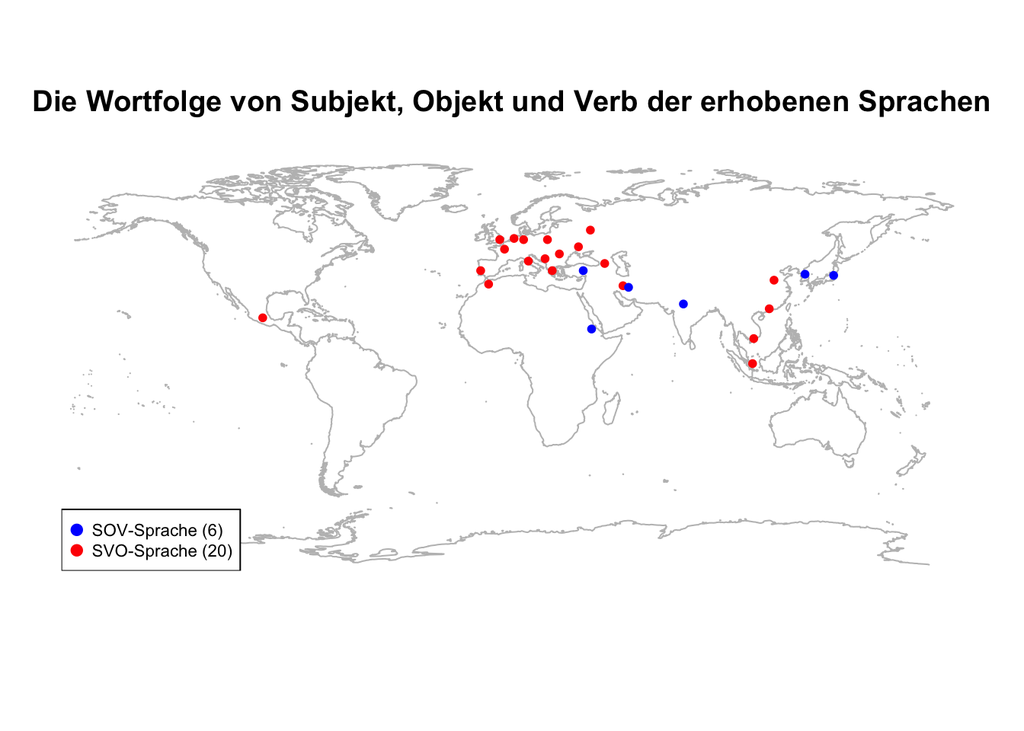

```r
maps::map("world"
          ,interior = FALSE
          , col = "grey"
          , resolution = 0)

cols <- c("blue", "red")
mycols <- cols[Umfragesdaten$Wortfolge]

mysymbols <- c(20, 20)
Wortfolge <- mysymbols[Umfragesdaten$Wortfolge]

freq <- table(Umfragesdaten$Wortfolge)
myname <- c(
      paste0("SOV-Sprache (", freq[1], ")")
    , paste0("SVO-Sprache (", freq[2], ")")
    )

points(Umfragesdaten$Longitude, Umfragesdaten$Latitude
       , pch = Wortfolge
       , col = mycols)

title(main = "Die Wortfolge von Subjekt, Objekt und Verb der erhobenen Sprachen")

legend ("bottomleft"
        , legend = myname
        , pch = Wortfolge
        , col = cols
        , cex = 0.7
        , pt.cex = 1.5)
```

Nicht nur auf Satz 1 “Ich koche Suppe” sondern auch alle andere Sätze berücksichtigt.

## 3.3 Die Wortstellungen in Nominalphrasen der erhobenen Sprachen

### 3.3.1 Die Reihenfolge von Adjektiv und Nomen in Nominalphrase

#### Bild 4: Die Reihenfolge von Adjektiv und Nomen in Nominalphrase

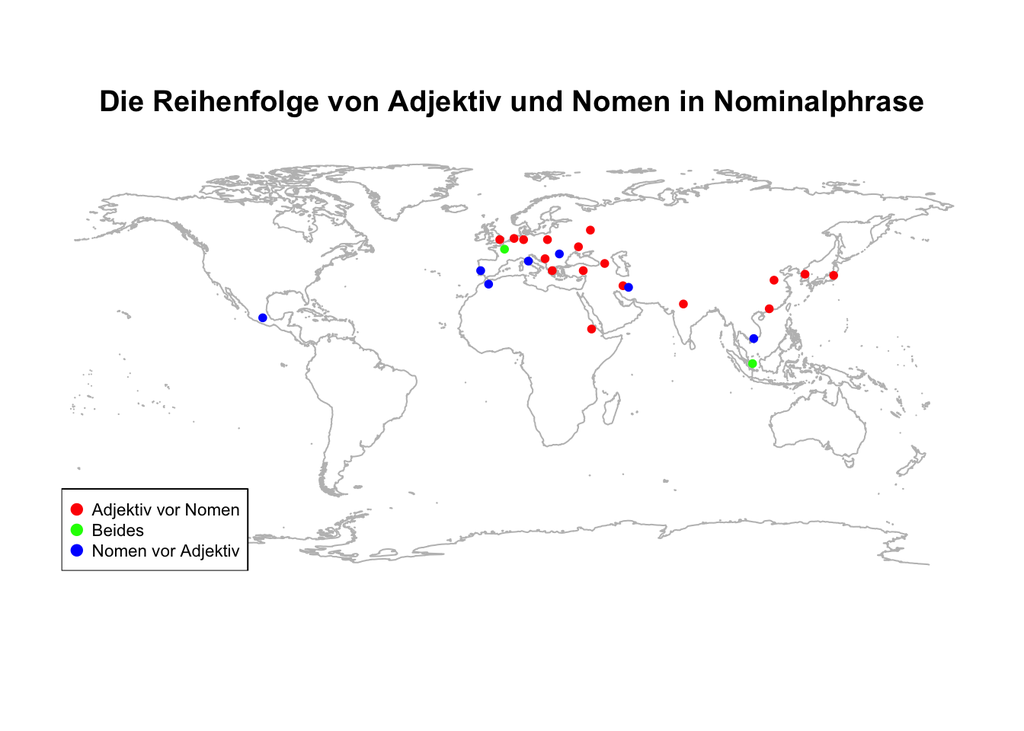

```r
maps::map("world"
          ,interior = FALSE
          , col = "grey"
          , resolution = 0)

cols <- c("red", "green", "blue")
mycols1 <- cols[Umfragesdaten$Adjektiv.Nomen]

mysymbols <- c(20, 20, 20)
AdjNon <- mysymbols[Umfragesdaten$Adjektiv.Nomen]

myname <- c("Adjektiv vor Nomen", "Beides", "Nomen vor Adjektiv")

points (Umfragesdaten$Longitude, Umfragesdaten$Latitude
       , pch = AdjNon
       , col = mycols1)

title(main = "Die Reihenfolge von Adjektiv und Nomen in Nominalphrase")

legend ("bottomleft"
        , legend = myname
        , pch = AdjNon
        , col = cols
        , cex = 0.7
        , pt.cex = 1.5)
```

### 3.3.2 Die Reihenfolge von Artikel und Nomen in Nominalphrase

#### Bild 5: Die Reihenfolge von Artikel und Nomen in Nominalphrase

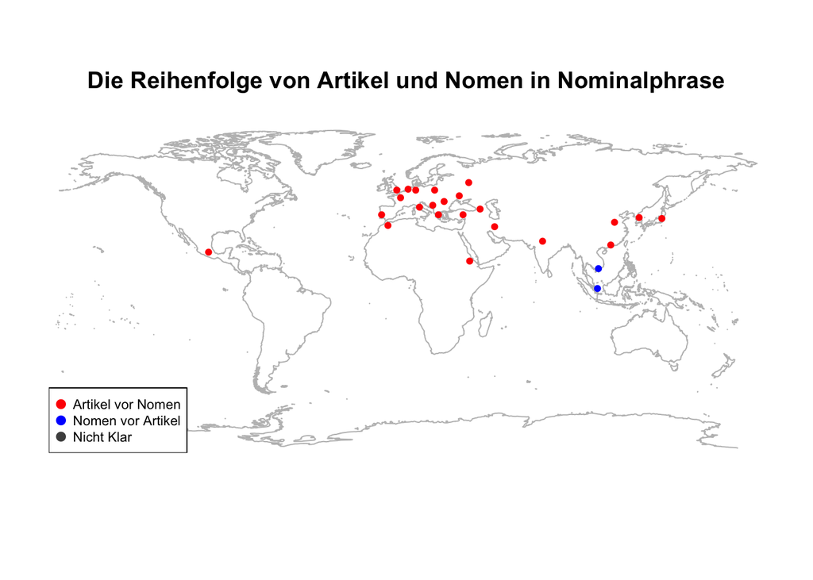

```r
maps::map("world"
          ,interior = FALSE
          , col = "grey"
          , resolution = 0)

cols <- c("red", "blue", "grey30")
mycols2 <- cols[Umfragesdaten$Artikel.Nomen]

mysymbols <- c(20, 20, 20)
ArtNon <- mysymbols[Umfragesdaten$Artikel.Nomen]

myname <- c("Artikel vor Nomen", "Nomen vor Artikel", "Nicht Klar")

points (Umfragesdaten$Longitude, Umfragesdaten$Latitude
       , pch = ArtNon
       , col = mycols2)

title(main = "Die Reihenfolge von Artikel und Nomen in Nominalphrase")

legend ("bottomleft"
        , legend = myname
        , pch = ArtNon
        , col = cols
        , cex = 0.7
        , pt.cex = 1.5)
```

Warum nicht klar? nicht eingegeben? nicht vorkommen? etc.

### 3.3.3 Die Reihenfolge von Farbe und Nomen in Nominalphrase “roter Ball”

#### Bild 6: Die Reihenfolge von Farbe und Nomen in Nominalphrase: roter Ball

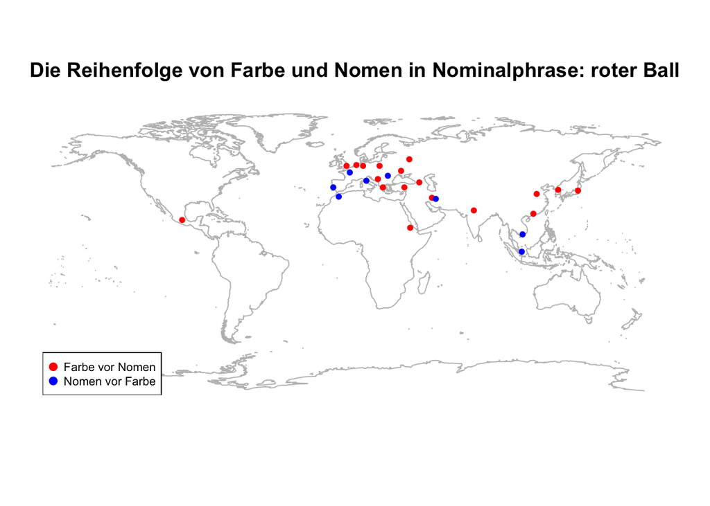

```r
maps::map("world"
          ,interior = FALSE
          , col = "grey"
          , resolution = 0)

cols <- c("red", "blue")
mycols3 <- cols[Umfragesdaten$Farbe.Nomen]

mysymbols <- c(20, 20)
FarbNon <- mysymbols[Umfragesdaten$Farbe.Nomen]

myname <- c("Farbe vor Nomen", "Nomen vor Farbe")

points (Umfragesdaten$Longitude, Umfragesdaten$Latitude
       , pch = FarbNon
       , col = mycols3)

title(main = "Die Reihenfolge von Farbe und Nomen in Nominalphrase: roter Ball")

legend ("bottomleft"
        , legend = myname
        , pch = FarbNon
        , col = cols
        , cex = 0.7
        , pt.cex = 1.5)
```

### 3.3.4 Die Reihenfolge von Numeral und Nomen in Nominalphrase “fünf Häuser”

#### Bild 7: Die Reihenfolge von Numeral und Nomen in Nominalphrase: fünf Häuser

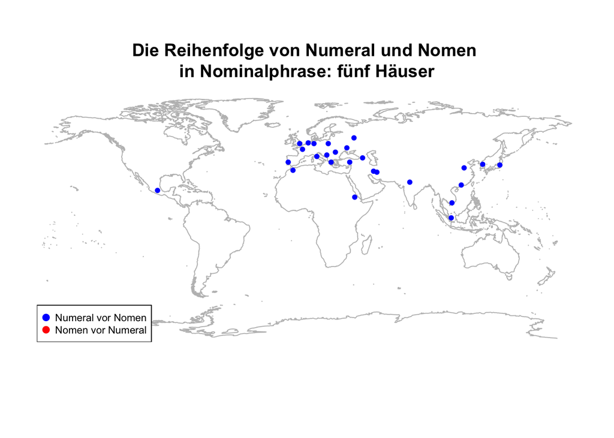

```r
maps::map("world"
          ,interior = FALSE
          , col = "grey"
          , resolution = 0)

cols <- c("blue", "red")
mycols4 <- cols[Umfragesdaten$Numeral.Nomen]

mysymbols <- c(20)
NumNon <- mysymbols[Umfragesdaten$Numeral.Nomen]

myname <- c("Numeral vor Nomen", "Nomen vor Numeral")

points (Umfragesdaten$Longitude, Umfragesdaten$Latitude
       , pch = NumNon
       , col = mycols4)

title(main = "Die Reihenfolge von Numeral und Nomen
in Nominalphrase: fünf Häuser")

legend ("bottomleft"
        , legend = myname
        , pch = NumNon
        , col = cols
        , cex = 0.7
        , pt.cex = 1.5)
```

In allen erhobenen Sprachen sind Numeral vor Nomen in Nominalphrase “fünf Häuser”, hier gibt es keine Ausnahme.

### 3.3.5 Die Wortfolge von Genitiv und Nomen in Nominalphrase “Musik von Mozart”

#### Bild 8: Die Wortfolge von Genitiv und Nomen in Nominalphrase: Musik von Mozart

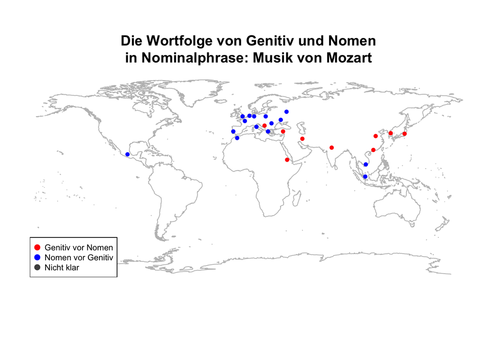

```r
maps::map("world"
          ,interior = FALSE
          , col = "grey"
          , resolution = 0)

cols <- c("red", "blue", "grey30")
mycols5 <- cols[Umfragesdaten$Musik.Mozart]

mysymbols <- c(20, 20, 20)
MuMo <- mysymbols[Umfragesdaten$Musik.Mozart]

myname <- c("Genitiv vor Nomen", "Nomen vor Genitiv", "Nicht klar")

points (Umfragesdaten$Longitude, Umfragesdaten$Latitude
       , pch = MuMo
       , col = mycols5)

title(main = "Die Wortfolge von Genitiv und Nomen
in Nominalphrase: Musik von Mozart")

legend ("bottomleft"
        , legend = myname
        , pch = MuMo
        , col = cols
        , cex = 0.7
        , pt.cex = 1.5)
```

## 3.4 Die Reihenfolge von verschiedenen Arten der Adjektiven in Nominalphrase

### 3.4.1 Die Reihenfolge von Artikel und Farbe in Nominalphrase “einen roten Ball”

#### Bild 9: Die Reihenfolge von Artikel und Farbe in Nominalphrase: einen roten Ball

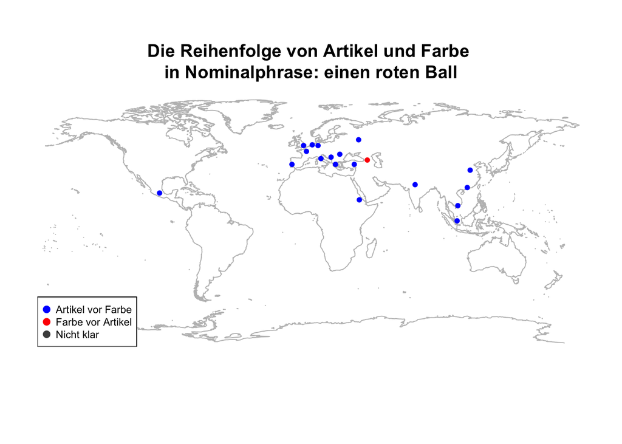

```r
maps::map("world"
          ,interior = FALSE
          , col = "grey"
          , resolution = 0)

cols <- c("blue", "red", "grey30")
mycols6 <- cols[Umfragesdaten$Artikel.Farbe]

mysymbols <- c(20, 20, 20)
ArtFa <- mysymbols[Umfragesdaten$Artikel.Farbe]

myname <- c("Artikel vor Farbe", "Farbe vor Artikel", "Nicht klar")

points (Umfragesdaten$Longitude, Umfragesdaten$Latitude
       , pch = ArtFa
       , col = mycols6)

title(main = "Die Reihenfolge von Artikel und Farbe
in Nominalphrase: einen roten Ball")

legend ("bottomleft"
        , legend = myname
        , pch = ArtFa
        , col = cols
        , cex = 0.7
        , pt.cex = 1.5)
```

### 3.4.2 Die Reihenfolge von Artikel und Numeral in Nominalphrase “diese fünf Häuser”

#### Bild 10: Die Reihenfolge von Artikel und Numeral in Nominalphrase: diese fünf Häuser

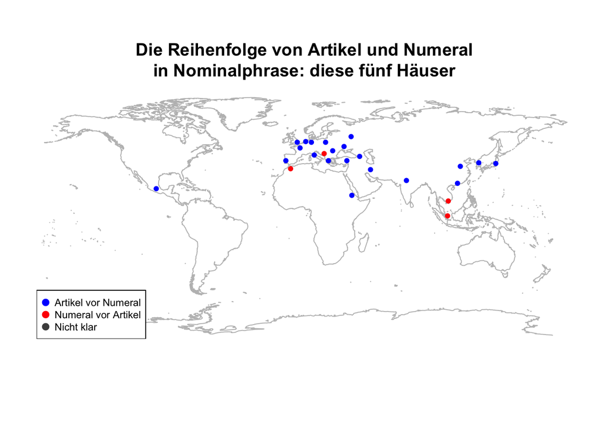

```r
maps::map("world"
          ,interior = FALSE
          , col = "grey"
          , resolution = 0)

cols <- c("blue", "red", "grey30")
mycols7 <- cols[Umfragesdaten$Artikel.Numeral]

mysymbols <- c(20, 20, 20)
ArtNum <- mysymbols[Umfragesdaten$Artikel.Numeral]

myname <- c("Artikel vor Numeral", "Numeral vor Artikel", "Nicht klar")

points (Umfragesdaten$Longitude, Umfragesdaten$Latitude
       , pch = ArtNum
       , col = mycols7)

title(main = "Die Reihenfolge von Artikel und Numeral
in Nominalphrase: diese fünf Häuser")

legend ("bottomleft"
        , legend = myname
        , pch = ArtNum
        , col = cols
        , cex = 0.7
        , pt.cex = 1.5)
```

### 3.4.3 Die Reihenfolge von Artikel und Adjektiv in Nominalphrase “das feuchte Holz”

#### Bild 11: Die Reihenfolge von Artikel und Adjektiv in Nominalphrase: das feuchte Holz

[figure not shown]

```r
maps::map("world"
          ,interior = FALSE
          , col = "grey"
          , resolution = 0)

cols <- c("blue", "red", "grey30")
mycols8 <- cols[Umfragesdaten$Artikel.Adjektiv]

mysymbols <- c(20, 20, 20)
ArtAdj <- mysymbols[Umfragesdaten$Artikel.Adjektiv]

myname <- c("Artikel vor Adjektiv", "Adjektiv vor Artikel", "Nicht klar")

points (Umfragesdaten$Longitude, Umfragesdaten$Latitude
       , pch = ArtAdj
       , col = mycols8)

title(main = "Die Reihenfolge von Artikel und Adjektiv
in Nominalphrase: das feuchte Holz")

legend ("bottomleft"
        , legend = myname
        , pch = ArtAdj
        , col = cols
        , cex = 0.7
        , pt.cex = 1.5)
```

### 3.4.4 Die Reihenfolge von Farbe und Adjektiv in Nominalphrase “schönen roten Ball”

#### Bild 12: Die Reihenfolge von Adjektiv und Farbe in Nominalphrase: schönen roten Ball

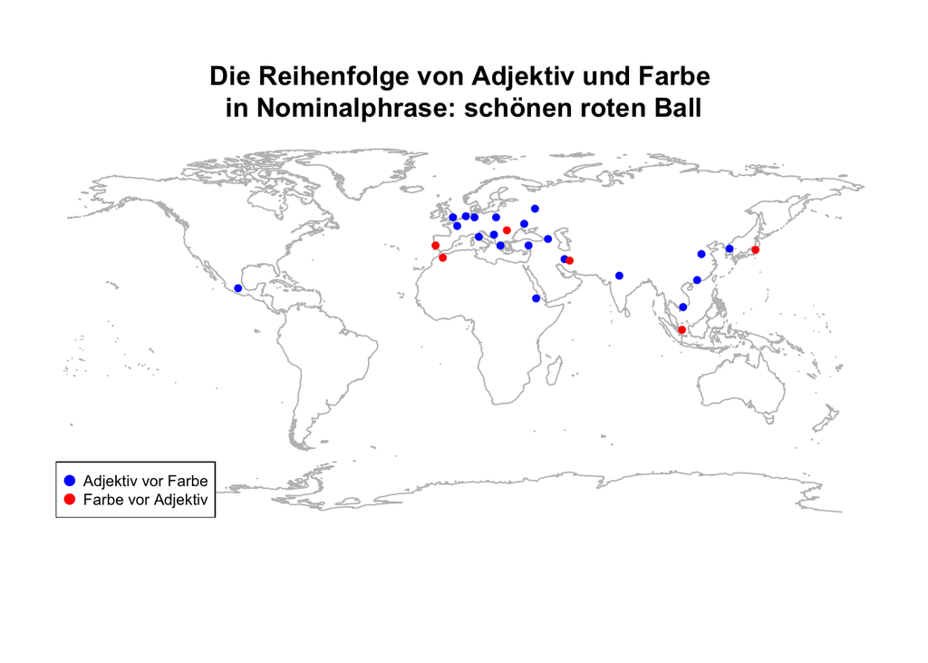

```r
maps::map("world"
          ,interior = FALSE
          , col = "grey"
          , resolution = 0)

cols <- c("blue", "red")
mycols9 <- cols[Umfragesdaten$Farbe.Adjektiv]

mysymbols <- c(20, 20)
FaAdj <- mysymbols[Umfragesdaten$Farbe.Adjektiv]

myname <- c("Adjektiv vor Farbe", "Farbe vor Adjektiv")

points (Umfragesdaten$Longitude, Umfragesdaten$Latitude
       , pch = FaAdj
       , col = mycols9)

title(main = "Die Reihenfolge von Adjektiv und Farbe
in Nominalphrase: schönen roten Ball")

legend ("bottomleft"
        , legend = myname
        , pch = FaAdj
        , col = cols
        , cex = 0.7
        , pt.cex = 1.5)
```

### 3.4.5 Die Reihenfolge von Adjektiv und Umfangsadjektiv in Nominalphrase “schönen großen Ball”

#### Bild 13: Die Reihenfolge von Adjektiv und Umfangsadjektiv in Nominalphrase: schönen großen Ball

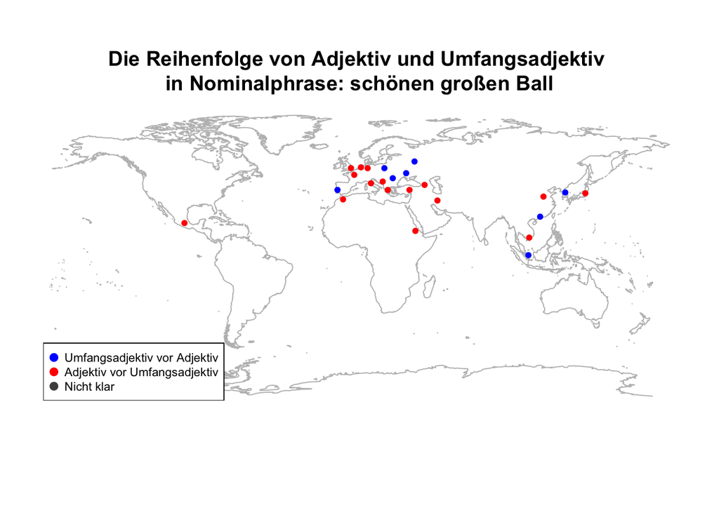

```r
maps::map("world"
          ,interior = FALSE
          , col = "grey"
          , resolution = 0)

cols <- c("blue", "red", "grey30")
mycols10 <- cols[Umfragesdaten$Adjektiv.Adjektiv.Umfang]

mysymbols <- c(20, 20, 20)
AdjAdjU <- mysymbols[Umfragesdaten$Adjektiv.Adjektiv.Umfang]

myname <- c("Umfangsadjektiv vor Adjektiv", "Adjektiv vor Umfangsadjektiv", "Nicht klar")

points (Umfragesdaten$Longitude, Umfragesdaten$Latitude
       , pch = AdjAdjU
       , col = mycols10)

title(main = "Die Reihenfolge von Adjektiv und Umfangsadjektiv
in Nominalphrase: schönen großen Ball")

legend ("bottomleft"
        , legend = myname
        , pch = AdjAdjU
        , col = cols
        , cex = 0.7
        , pt.cex = 1.5)
```

# 4. Zusammenhang zwischen den Wortfolgen und den Wortstellungen in Nominalphrasen der erhobenen Sprachen

**Vermutungen**

## 4.1 Zusammenhang zwischen den Wortfolgen und den Wortstellung der Adjektiv und Nomen

```r
str(Umfrage)
```

```
## 'data.frame':    26 obs. of  17 variables:
##  $ Sprache                 : Factor w/ 26 levels "Armenisch","Berber",..: 4 5 16 6 11 8 19 18 21 25 ...
##  $ Land                    : Factor w/ 24 levels "China","Deutschland",..: 2 3 16 5 11 7 18 17 20 23 ...
##  $ Gattung                 : Factor w/ 17 levels "Armenian","Berber",..: 4 4 4 12 12 5 12 15 15 15 ...
##  $ Familie                 : Factor w/ 10 levels "1 Indo-European",..: 1 1 1 1 1 1 1 1 1 1 ...
##  $ Latitude                : num  52 52 52.5 48 43 39 39 52 56 49 ...
##  $ Longitude               : num  10 0 6 2 12 22 -8 20 38 33 ...
##  $ Wortfolge               : Factor w/ 2 levels "1 SVO","2 SOV": 1 1 1 1 1 1 1 1 1 1 ...
##  $ Adjektiv.Nomen          : Factor w/ 4 levels "1 1 Adj+N","1 Adj+N",..: 1 2 2 4 3 2 3 2 2 2 ...
##  $ Musik.Mozart            : Factor w/ 2 levels "1 MuMo","2 MoMu": 1 1 1 1 1 1 1 1 1 1 ...
##  $ Artikel.Nomen           : Factor w/ 2 levels "1 DET+N","2 N+DET": 1 1 1 1 1 1 1 1 1 1 ...
##  $ Farbe.Nomen             : Factor w/ 2 levels "1 Fa+N","2 N+Fa": 1 1 1 2 2 1 2 1 1 1 ...
##  $ Numeral.Nomen           : Factor w/ 1 level "1 Num+N": 1 1 1 1 1 1 1 1 1 1 ...
##  $ Artikel.Farbe           : Factor w/ 2 levels "1 DET+Fa","2 Fa+DET": 1 1 1 1 1 1 1 NA 1 NA ...
##  $ Artikel.Numeral         : Factor w/ 2 levels "1 DET+Num","2 Num+DET": 1 1 1 1 1 1 1 1 1 1 ...
##  $ Artikel.Adjektiv        : Factor w/ 2 levels "1 DET+Adj","2 Adj+DET": 1 1 1 1 1 1 1 1 1 1 ...
##  $ Farbe.Adjektiv          : Factor w/ 2 levels "1 Adj+Fa","2 Fa+Adj": 1 1 1 1 1 1 2 1 1 1 ...
##  $ Adjektiv.Adjektiv.Umfang: Factor w/ 2 levels "1 Adj+Adj-U",..: 1 1 1 1 1 1 2 2 2 2 ...
```

```r
head(Umfrage)
```

```
##          Sprache        Land  Gattung         Familie Latitude Longitude
## 1        Deutsch Deutschland Germanic 1 Indo-European     52.0        10
## 2       Englisch     England Germanic 1 Indo-European     52.0         0
## 3 Niederländisch  Niederland Germanic 1 Indo-European     52.5         6
## 4    Französisch  Frankreich  Romance 1 Indo-European     48.0         2
## 5    Italienisch     Italien  Romance 1 Indo-European     43.0        12
## 6     Griechisch  Griechland    Greek 1 Indo-European     39.0        22
##   Wortfolge      Adjektiv.Nomen Musik.Mozart Artikel.Nomen Farbe.Nomen
## 1     1 SVO           1 1 Adj+N       1 MuMo       1 DET+N      1 Fa+N
## 2     1 SVO             1 Adj+N       1 MuMo       1 DET+N      1 Fa+N
## 3     1 SVO             1 Adj+N       1 MuMo       1 DET+N      1 Fa+N
## 4     1 SVO 3 No dominant order       1 MuMo       1 DET+N      2 N+Fa
## 5     1 SVO             2 N+Adj       1 MuMo       1 DET+N      2 N+Fa
## 6     1 SVO             1 Adj+N       1 MuMo       1 DET+N      1 Fa+N
##   Numeral.Nomen Artikel.Farbe Artikel.Numeral Artikel.Adjektiv
## 1       1 Num+N      1 DET+Fa       1 DET+Num        1 DET+Adj
## 2       1 Num+N      1 DET+Fa       1 DET+Num        1 DET+Adj
## 3       1 Num+N      1 DET+Fa       1 DET+Num        1 DET+Adj
## 4       1 Num+N      1 DET+Fa       1 DET+Num        1 DET+Adj
## 5       1 Num+N      1 DET+Fa       1 DET+Num        1 DET+Adj
## 6       1 Num+N      1 DET+Fa       1 DET+Num        1 DET+Adj
##   Farbe.Adjektiv Adjektiv.Adjektiv.Umfang
## 1       1 Adj+Fa              1 Adj+Adj-U
## 2       1 Adj+Fa              1 Adj+Adj-U
## 3       1 Adj+Fa              1 Adj+Adj-U
## 4       1 Adj+Fa              1 Adj+Adj-U
## 5       1 Adj+Fa              1 Adj+Adj-U
## 6       1 Adj+Fa              1 Adj+Adj-U
```

# 5. Allgemeine Diskussion und Ausblick

Kritik In vielen Sprachen sind die Bedeutung von jedem Wort nicht klar markiert oder geschrieben, wie Persisch, Koreanisch. Man kann nur mit Wörterbuch und Google Übersetzer die Bedeutung vom einzelnen Wort raussuchen, aber meistens ist man unsicher. Daher kann man nur die Art von Wort feststellen, nicht die genaue Bedeutung und Feinheit.

Satz 1: Ich koche Suppe. In Vielen Sprachen wird der Subjekt nicht eingegeben, wenn es “ich” ist. “Ich” als Subjekt wird in der Endung von Verb makiert.

# Literatur- und Quellenverzeichnis

- Koordinate für die erhobenen Sprachen: http://wals.info/languoid (aufgerufen am 22.02.2018)